# Exercise Performance

Lavnish Singh Bisht

The goal of the project is to predict the manner in which they did the exercise. the “classe” variable in the dataset represents that variable.

```r
library(readr)
training <- read_csv("pml-training.csv")
testing <- read_csv("pml-testing.csv")
```

as can be seen in this data their too many columns and so many of them have no data(NA) so the columns which have more than 19000 observations empty should be removed

```r
library(caret)
a=1
b=1
for(i in c(1:160))
{  if(sum(is.na(training[,i]))>19000)
{b[a]= i
a=a+1}}
training= training[,-b]
testing= testing[,-b]
dim(training)
```

```
## [1] 19622    60
```

we can see now their are only 60 columns

Some exploraty data analysis

```r
str(training)
```

```
## tibble [19,622 x 60] (S3: tbl_df/tbl/data.frame)
##  $ X1                  : num [1:19622] 1 2 3 4 5 6 7 8 9 10 ...
##  $ user_name           : chr [1:19622] "carlitos" "carlitos" "carlitos" "carlitos" ...
##  $ raw_timestamp_part_1: num [1:19622] 1.32e+09 1.32e+09 1.32e+09 1.32e+09 1.32e+09 ...
##  $ raw_timestamp_part_2: num [1:19622] 788290 808298 820366 120339 196328 ...
##  $ cvtd_timestamp      : chr [1:19622] "5/12/2011 11:23" "5/12/2011 11:23" "5/12/2011 11:23" "5/12/2011 11:23" ...
##  $ new_window          : chr [1:19622] "no" "no" "no" "no" ...
##  $ num_window          : num [1:19622] 11 11 11 12 12 12 12 12 12 12 ...
##  $ roll_belt           : num [1:19622] 1.41 1.41 1.42 1.48 1.48 1.45 1.42 1.42 1.43 1.45 ...
##  $ pitch_belt          : num [1:19622] 8.07 8.07 8.07 8.05 8.07 8.06 8.09 8.13 8.16 8.17 ...
##  $ yaw_belt            : num [1:19622] -94.4 -94.4 -94.4 -94.4 -94.4 -94.4 -94.4 -94.4 -94.4 -94.4 ...
##  $ total_accel_belt    : num [1:19622] 3 3 3 3 3 3 3 3 3 3 ...
##  $ gyros_belt_x        : num [1:19622] 0 0.02 0 0.02 0.02 0.02 0.02 0.02 0.02 0.03 ...
##  $ gyros_belt_y        : num [1:19622] 0 0 0 0 0.02 0 0 0 0 0 ...
##  $ gyros_belt_z        : num [1:19622] -0.02 -0.02 -0.02 -0.03 -0.02 -0.02 -0.02 -0.02 -0.02 0 ...
```

[output cut: 52 more lines]

```r
unique(training$user_name)
```

```
## [1] "carlitos" "pedro"    "adelmo"   "charles"  "eurico"   "jeremy"
```

Deleting the columns with useless information for prediction model - like name, time, window etc i.e from column 1-7

```r
training= training[,-c(1:7)]
testing= testing[,-c(1:7)]
```

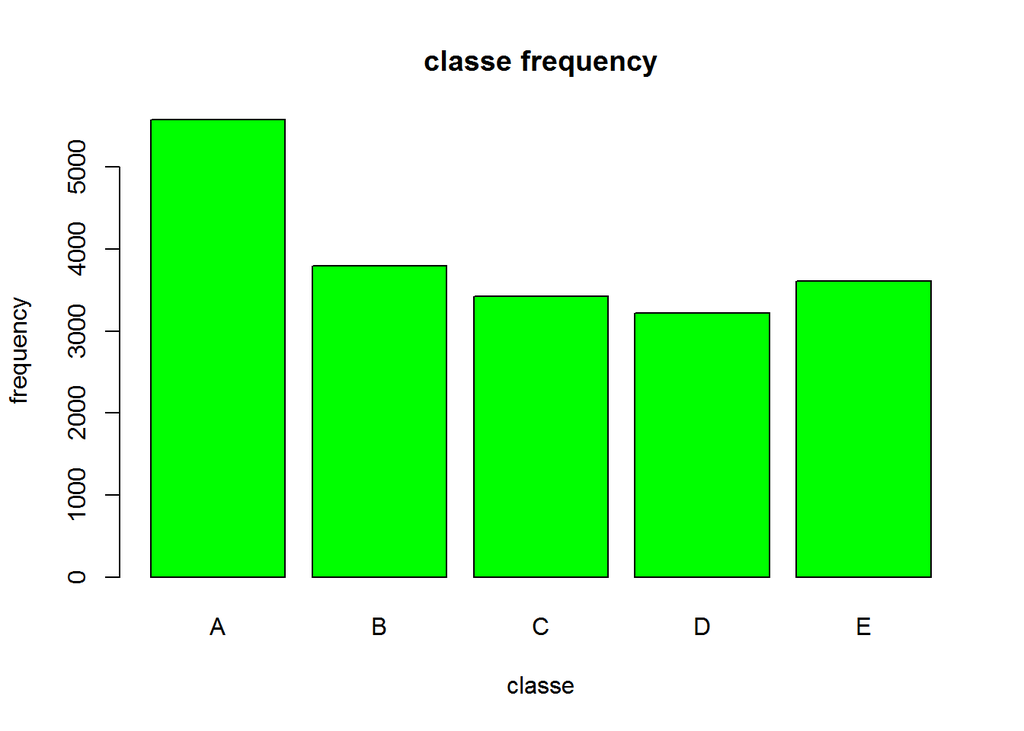

```r
training$classe= factor(training$classe)
plot(training$classe, col="green", main = "classe frequency", xlab = "classe", ylab = "frequency")
```

we will prepare validation dataset for cross validation and name it “vald”

```r
ind= createDataPartition(training$classe, p=.75,list = FALSE)
ind= as.numeric(ind)
vald= training[-ind,]
training= training[ind,]
```

now we will build models to predict the classe of the observation

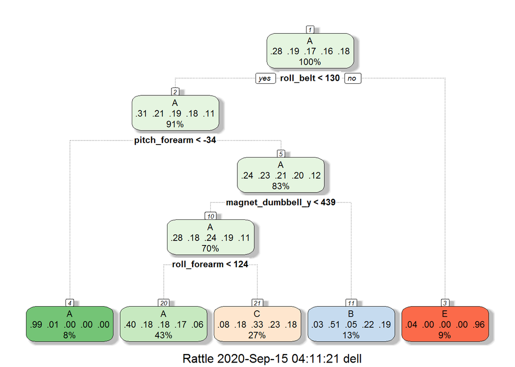

```r
library(rpart.plot)
library(rattle)
modelrp= train(classe~., data= training, method="rpart")
predrp= predict(modelrp, vald)
fancyRpartPlot(modelrp$finalModel)
```

```r
confusionMatrix(predrp, vald$classe)
```

```
## Confusion Matrix and Statistics
##
##           Reference
## Prediction    A    B    C    D    E
##          A 1246  405  412  355  117
##          B   24  321   22  151  105
##          C  104  223  421  298  225
##          D    0    0    0    0    0
##          E   21    0    0    0  454
##
## Overall Statistics
##
##                Accuracy : 0.498
##                  95% CI : (0.4839, 0.5121)
##     No Information Rate : 0.2845
##     P-Value [Acc > NIR] : < 2.2e-16
##
##                   Kappa : 0.3441
##
##  Mcnemar's Test P-Value : NA
##
## Statistics by Class:
##
##                      Class: A Class: B Class: C Class: D Class: E
## Sensitivity            0.8932  0.33825  0.49240   0.0000  0.50388
## Specificity            0.6327  0.92364  0.79007   1.0000  0.99475
## Pos Pred Value         0.4915  0.51525  0.33124      NaN  0.95579
## Neg Pred Value         0.9371  0.85331  0.88054   0.8361  0.89907
## Prevalence             0.2845  0.19352  0.17435   0.1639  0.18373
## Detection Rate         0.2541  0.06546  0.08585   0.0000  0.09258
## Detection Prevalence   0.5169  0.12704  0.25918   0.0000  0.09686
## Balanced Accuracy      0.7629  0.63095  0.64123   0.5000  0.74932
```

```r
modld= train(classe~., data= training, method="lda")
predlda= predict(modld, vald)
confusionMatrix(predlda, vald$classe)
```

```
## Confusion Matrix and Statistics
##
##           Reference
## Prediction    A    B    C    D    E
##          A 1123  134   96   51   32
##          B   23  617   83   33  151
##          C  135  119  550  102   79
##          D  109   36   91  580   78
##          E    5   43   35   38  561
##
## Overall Statistics
##
##                Accuracy : 0.6996
##                  95% CI : (0.6866, 0.7124)
##     No Information Rate : 0.2845
##     P-Value [Acc > NIR] : < 2.2e-16
##
##                   Kappa : 0.62
##
##  Mcnemar's Test P-Value : < 2.2e-16
##
## Statistics by Class:
##
##                      Class: A Class: B Class: C Class: D Class: E
## Sensitivity            0.8050   0.6502   0.6433   0.7214   0.6226
## Specificity            0.9108   0.9267   0.8926   0.9234   0.9698
## Pos Pred Value         0.7820   0.6803   0.5584   0.6488   0.8226
## Neg Pred Value         0.9216   0.9169   0.9222   0.9441   0.9195
## Prevalence             0.2845   0.1935   0.1743   0.1639   0.1837
## Detection Rate         0.2290   0.1258   0.1122   0.1183   0.1144
## Detection Prevalence   0.2928   0.1850   0.2009   0.1823   0.1391
## Balanced Accuracy      0.8579   0.7884   0.7679   0.8224   0.7962
```

we have built 2 models and compared the accuracy

and lilnear discreminative analsis has better accuracy so is the finalmodel predictions of testing data from final model

```r
results=predict(modld,newdata =testing)
results
```

```
##  [1] B A B C C E D D A A D A B A E A A B B B
## Levels: A B C D E
```